[figure not shown]

# Revisiting xmas kindle draw

Posted on Mon 18 November 2019 in analysis

Using jupyter notebook, to figure out how to draw our next christmas kindle.

# A very simple kindle draw

Revisiting the simple kindle draw. And getting utterly confused.

```python
import random

def simple_secret_santa(names,printit=False):
    n = len(names)
    s = random.sample(names,k=n)
    out = []
    for i,name in enumerate(s):
        if i == len(s)-1:
            to = s[0]
        else:
            to = s[i+1]
        out.append(name+'-'+to)
        if printit:
            print(str(i+1) + "   "+name + ' gives to ' + to)
    return out
```

```python
names = ['Ro','Pa','Ao','HaM',
        'Fi', 'Ci',
        'Te','Ja','Ch','HaC',
        'Co','An','It',
        'To',
        'Et',
        'Ro', 'Li']
```

```python
s = simple_secret_santa(names,printit=True)
```

```
1   Ja gives to It
2   It gives to Pa
3   Pa gives to An
4   An gives to HaM
5   HaM gives to Co
6   Co gives to Ro
7   Ro gives to Ch
8   Ch gives to Ci
9   Ci gives to Ro
10   Ro gives to Ao
11   Ao gives to Fi
12   Fi gives to To
13   To gives to Te
14   Te gives to Li
15   Li gives to Et
16   Et gives to HaC
17   HaC gives to Ja
```

# How random is this ?

First lets import matplotlib package so we can do some vizualisation.

```python
%matplotlib inline
import matplotlib.pyplot as plt
import matplotlib.gridspec as gridspec
import numpy as np
import itertools
```

```python
def monte_carlo(names,n=1000):
    comb = {name1+'-'+name2:0 for name1,name2 in itertools.permutations(names,2)}
    for i in range(n):
        for couple in simple_secret_santa(names):
            comb[couple] += 1
    fig1 = plt.figure()
    plt.plot([comb[k] for k in comb.keys()])
    plt.xlabel('Iterations')
    plt.ylabel('Count each combo')
    #plt.axhline(y=n, color='r', linestyle='-')
    plt.title('Xmas Kindle')
    plt.show()
    return comb
```

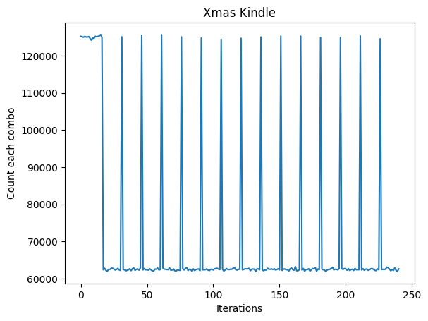

```python
c = monte_carlo(names,n=1000000)
```

That is very odd, I would have expected each combination to appear roughly the same number of times, it looks like some combination are twice as frequent ? ... Let's try with a smaller set.

```python
names2 = ['Jolene','Niamh','Sophie','Lorraine','Paschal']
#only 5 people in the draw, which should make 20 possible donor combinations
comb2 = {name1+'-'+name2:0 for name1,name2 in itertools.permutations(names2,2)}
print(len(comb2))
```

```
20
```

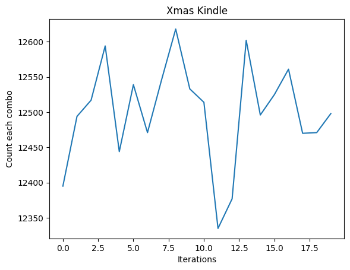

```python
c2 = monte_carlo(names2,n=50000)
```

This looks about right.Let's used a reduced inital set.

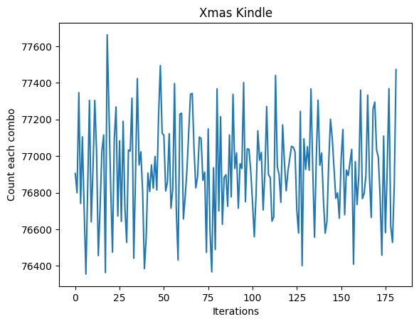

```python
c_Reduced = monte_carlo(names[:14],n=1000000)
```

Again this looks more as expected, after inspecting the initial names selection, I actually realized the name were not uniques.

```python
duplicates = [names.count(n)>=2 for n in names]
print(duplicates)
```

```
[True, False, False, False, False, False, False, False, False, False, False, False, False, False, False, True, False]
```

```
20
```

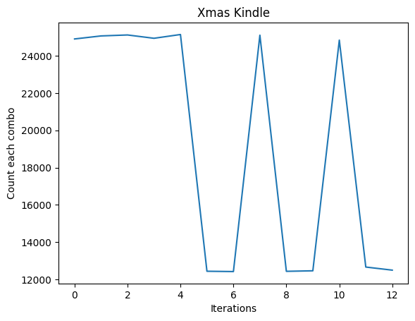

```python
# Replicating the issue with duplicate names
names3 = ['Jolene','Niamh','Sophie','Lorraine','Jolene']
#only 5 people in the draw, which should make 20 possible donor combinations, with a duplicate
comb3 = {name1+'-'+name2:0 for name1,name2 in itertools.permutations(names3,2)}
print(len(comb2))
c3 = monte_carlo(names3,n=50000)
```

```python
#This explain the disruption in randomness so we can easily fix that by adding a check for name uniqueness
def isThereDuplicates(names):
    dups = [names.count(n)>=2 for n in names]
    if any(dups):
        print("Duplicate names")
        print(names[dups.index(True)])
        return True
    else:
        return False

isThereDuplicates(names)
```

```
Duplicate names
Ro
```

```
True
```

```python
# Fixing the duplicates

def simple_secret_santa(names,printit=False):
    n = len(names)
    s = random.sample(names,k=n)
    out = []
    if not isThereDuplicates(names):
        for i,name in enumerate(s):
            if i == len(s)-1:
                to = s[0]
            else:
                to = s[i+1]
            out.append(name+'-'+to)
            if printit:
                print(str(i+1) + "   "+name + ' gives to ' + to)
    return out
```

# Family draws

However for a family draw, you may want to avoid gift between siblings ( my particular family case ) or between partners (not considered here), so only gift to cousin are allowed, to do this I am introducing a dictionary, with the name of the parent as value and the kid name as key.

```python
def simple_secret_santa_avoid_siblings(names):
    givers = list(names.keys())
    recipients = []
    s = random.sample(givers,k=len(givers))
    out = []
    if not isThereDuplicates(list(givers)):
        for i,name in enumerate(s):
            possible = [r for r in names.keys() if (names[r] != names[name] and r not in recipients)]
            recipient = random.sample(possible,k=1)[0]
            recipients.append(recipient)
            print(str(i+1) + ': ' + name + ' gives to ' + recipient + ' ::: '+ str(len(recipients))+':'+str(len(possible)))
            out.append(name+'-'+recipient)
        #Check
        print('Recipients: '+str(len(recipients))+':: names:'+str(len(names.keys())))
```

```python
names_siblings = {'Child1':'Parent1','Child2':'Parent1','Child3':'Parent1','Child4':'Parent1',
        'Child5':'Parent2', 'Child6':'Parent2',
        'Child7':'Parent3','Child8':'Parent3','Child9':'Parent3','Child10':'Parent3',
        'Child11':'Parent4','Child12':'Parent4','Child13':'Parent4',
        'Child14':'Parent5',
        'Child15':'Parent6',
        'Child16':'Parent7', 'Child17':'Parent7'}
```

```python
simple_secret_santa_avoid_siblings(names_siblings)
```

```
1: Child11 gives to Child7 ::: 1:14
2: Child5 gives to Child2 ::: 2:14
3: Child16 gives to Child1 ::: 3:13
4: Child9 gives to Child11 ::: 4:11
5: Child10 gives to Child5 ::: 5:10
6: Child12 gives to Child9 ::: 6:10
7: Child3 gives to Child8 ::: 7:9
8: Child13 gives to Child6 ::: 8:8
9: Child15 gives to Child10 ::: 9:8
10: Child8 gives to Child12 ::: 10:8
11: Child2 gives to Child16 ::: 11:5
12: Child1 gives to Child15 ::: 12:4
13: Child4 gives to Child14 ::: 13:3
14: Child6 gives to Child17 ::: 14:4
15: Child14 gives to Child13 ::: 15:3
16: Child17 gives to Child3 ::: 16:2
17: Child7 gives to Child4 ::: 17:1
Recipients: 17:: names:17
```

Python